# Practice 7.1

# Visualization

## Layouts

### Loading needed libraries

Load the xUCINET and statnet libraries

```r
library(xUCINET)
library(statnet)
```

### The Krackhardt dataset

We will be using the Krackhardt dataset

```r
Krackhardt_HighTech$ProjectInfo
```

```
$ProjectName
[1] "Krackhardt_HighTech."

$GeneralDescription
[1] "These are data collected by David Krackhardt among the managers of a high-tech company. The company manufactured high-tech equipment on the West Coast of the United States and had just over 100 employees with 21 managers. Contains three types of network relations and four attributes."

$AttributesDescription
[1] "Age:        the managers age (in years)"
[2] "Tenure:     the length of service or tenure (in years)"
[3] "Level:      the level in the corporate hierarchy (coded 1=CEO, 2=Vice President, 3=Manager)"
[4] "Department: a nominal coding for the department (coded 1, 2, 3, 4, with the CEO in department 0, i.e., not in a department)"

$NetworksDescription
[1] "Advice:     who the manager went to for advice"                         "Friendship: who the manager considers a friend"
[3] "ReportTo:   whom the manager reported to, taken from company documents"

$References
[1] "Krackhardt D. (1987). Cognitive social structures. Social Networks, 9, 104-134."
[2] "Wasserman S and K Faust (1994). Social Network Analysis: Methods and Applications. Cambridge University Press, Cambridge."
```

### The Friendship network

Create a minimum symmetrized network from the Friendship network.

```r
Krackhardt_HighTech$Friendship_SymMin <- xSymmetrize(Krackhardt_HighTech$Friendship, Type="Min")
```

Plot the symmetrized Friendship network with random layout

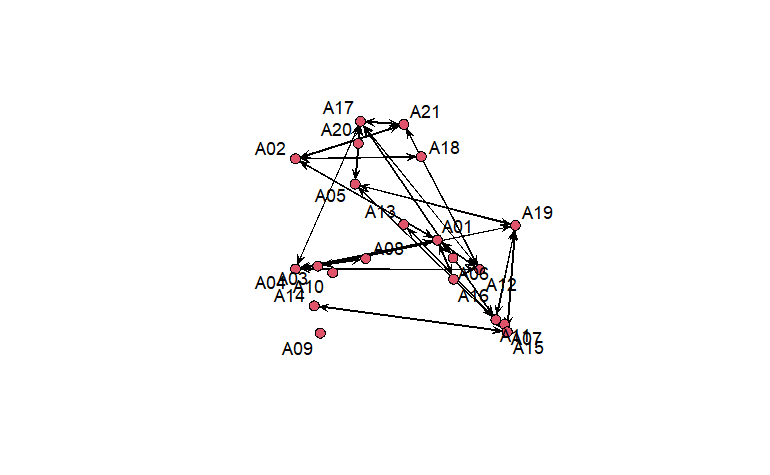

```r
gplot(Krackhardt_HighTech$Friendship_SymMin, mode="random", vertex.col=2, displaylabels = TRUE)
```

- There are lots of issues with this layout. It is hard to see the connections between the nodes.
- For a relatively small network, the circle layout is often the most informative
- Plot the symmetrized Frienship network with circle layout

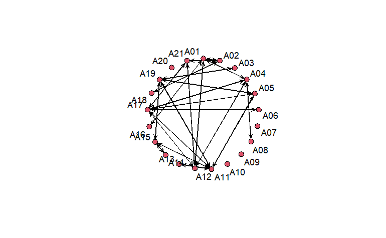

```r
gplot(Krackhardt_HighTech$Friendship_SymMin, mode="circle", vertex.col=2, displaylabels = TRUE)
```

- The fruchterman-reingold layout is a graph layout algorithm It is a force-directed layout algorithm that places the vertices of a graph on a plane in such a way that all the edges are of more or less equal length and there are as few crossing edges as possible.
- It is the default layout for the gplot function
- Meaning that if you do not specify a layout, the fruchterman-reingold layout will be used.

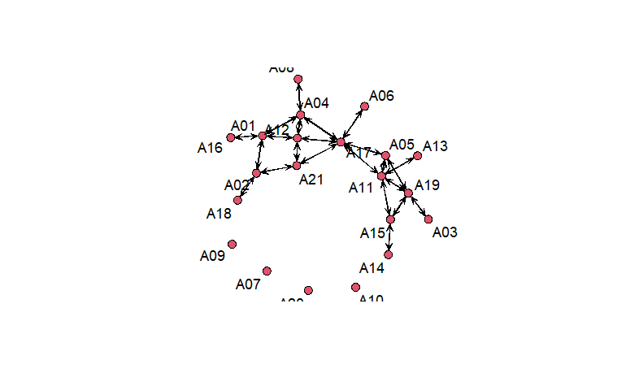

```r
gplot(Krackhardt_HighTech$Friendship_SymMin, vertex.col=2, displaylabels = TRUE)
```

A better visualization

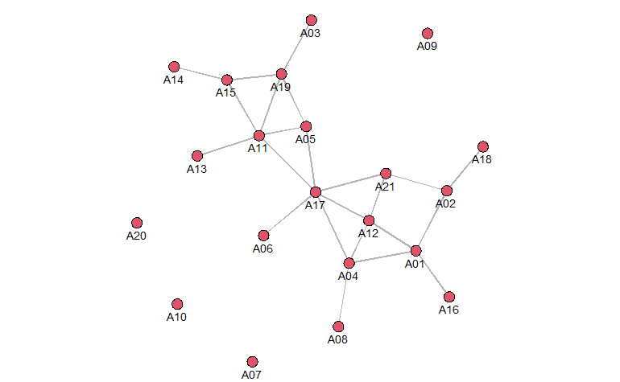

```r
par(mar=c(0,0,0,0))
gplot(Krackhardt_HighTech$Friendship_SymMin,
      gmode = "graph",
      vertex.cex = 0.8,
      displaylabels = TRUE,
      label.pos = 1,
      label.cex = 0.8,
      edge.col = "grey70"
      )
```

### The Advice network

Create a minimum symmetrized network from the Advice network

```r
Krackhardt_HighTech$Advice_SymMin <- xSymmetrize(Krackhardt_HighTech$Advice, Type="Min")
```

Plot

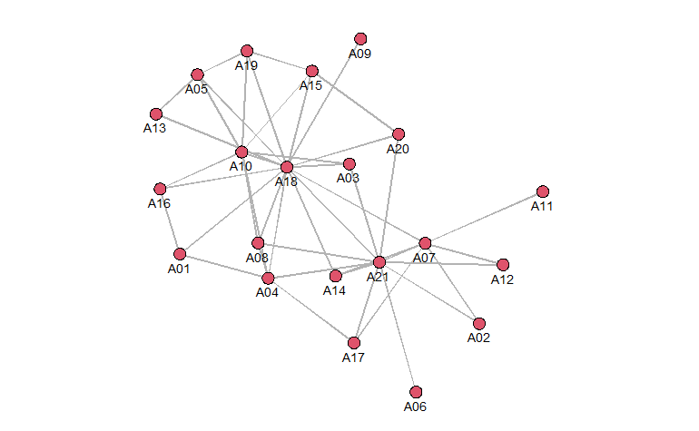

```r
par(mar=c(0,0,0,0))
gplot(Krackhardt_HighTech$Advice_SymMin,
      gmode = "graph",
      vertex.cex = 0.8,
      displaylabels = TRUE,
      label.pos = 1,
      label.cex = 0.8,
      edge.col = "grey70"
)
```

## Layouts based on node attributes

### Using continuous attributes

Examples: age, rank, experience, etc…

#### Using the Wolfe-Primates network

Check the attributes of this network

```r
Wolfe_Primates$Attributes
```

|  | Gender | Age | Rank |
| --- | --- | --- | --- |
| A01 | 1 | 15 | 1 |
| A02 | 1 | 10 | 2 |
| A03 | 1 | 10 | 3 |
| A04 | 1 | 8 | 4 |
| A05 | 1 | 7 | 5 |
| A06 | 2 | 15 | 10 |
| A07 | 2 | 5 | 11 |
| A08 | 2 | 11 | 6 |
| A09 | 2 | 8 | 12 |
| A10 | 2 | 9 | 9 |

[output cut: 10 more lines]

- The network data are valued and represent how often two monkeys were seen together.
- We decided to dichotomize the network so that only stronger ties are visible.
- To decide the cutoff, we inspect the distribution of tie strengths using the
- table() function (note that diagonals are 0, and are included in the frequency distribution):

```r
table(Wolfe_Primates$JointPresence)
```

```
 0  1  2  3  4  5  6  7  8  9 10 11 14 17
38 52 60 72 58 42 16 20 14 12  2 10  2  2
```

```r
par(mar=c(0,0,0,0))
gplot(Wolfe_Primates$JointPresence >= 7,
      gmode = "graph",
      coord = Wolfe_Primates$Attributes[, 2:3],
      vertex.cex = 0.8,
      vertex.col=(Wolfe_Primates$Attributes$Gender==1)*8,
      displaylabels = TRUE,
      label.pos = 1,
      label.cex = 0.7,
      edge.col = "grey70"
      )
arrows(0,
       (max(Wolfe_Primates$Attributes$Age)+min(Wolfe_Primates$Attributes$Age)),
       0,
       0,
       length = 0.1)
```

```r
arrows(0,
       0,
       (max(Wolfe_Primates$Attributes[,2])+min(Wolfe_Primates$Attributes[,2])),
       0,
       length = 0.1)
text(0,
     (max(Wolfe_Primates$Attributes$Rank)+min(Wolfe_Primates$Attributes$Rank)),
     labels="Rank",
     cex=0.8,
     pos=4)
```

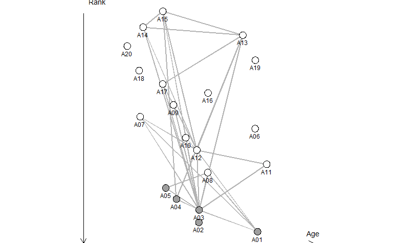

```r
text((max(Wolfe_Primates$Attributes$Age)+min(Wolfe_Primates$Attributes$Age)),.2,
     labels="Age",
     cex=0.8,
     pos=3)
```

### Using categorical attributes

We will create a matrix where we would have a value 1 when two nodes belong to the same category and 0 if they don’t and we would use this to generate the positions of the nodes in the figure

Back to the Friendship network

```r
MATRIX_A1 <-matrix(Krackhardt_HighTech$Attributes$Department,dim(Krackhardt_HighTech$Friendship)[1],dim(Krackhardt_HighTech$Friendship)[1])
MATRIX_A2 <-(MATRIX_A1==t(MATRIX_A1))*1
MATRIX_A2
```

```
      [,1] [,2] [,3] [,4] [,5] [,6] [,7] [,8] [,9] [,10] [,11] [,12] [,13] [,14] [,15] [,16] [,17] [,18] [,19] [,20] [,21]
 [1,]    1    1    0    1    0    0    0    0    0     0     0     0     0     0     0     1     0     0     0     0     0
 [2,]    1    1    0    1    0    0    0    0    0     0     0     0     0     0     0     1     0     0     0     0     0
 [3,]    0    0    1    0    1    0    0    0    1     0     0     0     1     1     1     0     0     0     1     1     0
 [4,]    1    1    0    1    0    0    0    0    0     0     0     0     0     0     0     1     0     0     0     0     0
 [5,]    0    0    1    0    1    0    0    0    1     0     0     0     1     1     1     0     0     0     1     1     0
 [6,]    0    0    0    0    0    1    0    1    0     0     0     1     0     0     0     0     1     0     0     0     1
 [7,]    0    0    0    0    0    0    1    0    0     0     0     0     0     0     0     0     0     0     0     0     0
 [8,]    0    0    0    0    0    1    0    1    0     0     0     1     0     0     0     0     1     0     0     0     1
 [9,]    0    0    1    0    1    0    0    0    1     0     0     0     1     1     1     0     0     0     1     1     0
[10,]    0    0    0    0    0    0    0    0    0     1     1     0     0     0     0     0     0     1     0     0     0
[11,]    0    0    0    0    0    0    0    0    0     1     1     0     0     0     0     0     0     1     0     0     0
[12,]    0    0    0    0    0    1    0    1    0     0     0     1     0     0     0     0     1     0     0     0     1
[13,]    0    0    1    0    1    0    0    0    1     0     0     0     1     1     1     0     0     0     1     1     0
[14,]    0    0    1    0    1    0    0    0    1     0     0     0     1     1     1     0     0     0     1     1     0
[15,]    0    0    1    0    1    0    0    0    1     0     0     0     1     1     1     0     0     0     1     1     0
[16,]    1    1    0    1    0    0    0    0    0     0     0     0     0     0     0     1     0     0     0     0     0
[17,]    0    0    0    0    0    1    0    1    0     0     0     1     0     0     0     0     1     0     0     0     1
[18,]    0    0    0    0    0    0    0    0    0     1     1     0     0     0     0     0     0     1     0     0     0
[19,]    0    0    1    0    1    0    0    0    1     0     0     0     1     1     1     0     0     0     1     1     0
[20,]    0    0    1    0    1    0    0    0    1     0     0     0     1     1     1     0     0     0     1     1     0
[21,]    0    0    0    0    0    1    0    1    0     0     0     1     0     0     0     0     1     0     0     0     1
```

Get the coordinates of the matrix

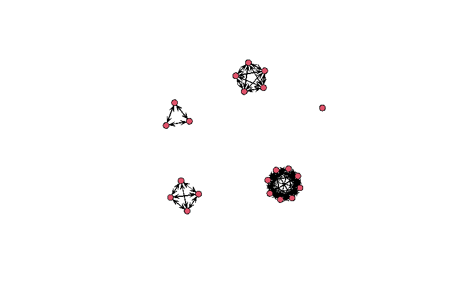

```r
COORD_A2 <- gplot(MATRIX_A2)
```

This will plot the nodes in the same department close to each other and nodes in different department far from each other.

Plot the friendship and advice relationships among the nodes with the above layout

```r
# Plot the friendship edges
op <- par(mar = c(0, 0, 0, 0), mfrow=c(1,2))
gplot(Krackhardt_HighTech$Friendship_SymMin,
      gmode="graph",
      coord=COORD_A2,
      vertex.cex=.8,
      displaylabels=TRUE,
      label.pos=1,
      label.cex=.7,
      edge.col="grey70")

# Plot the advice edges
gplot((Krackhardt_HighTech$Advice)*t(Krackhardt_HighTech$Advice),
      gmode="graph",
      coord=COORD_A2,
      vertex.cex=.8,
      displaylabels=TRUE,
      label.pos=1,
      label.cex=.7,
      edge.col="grey70")
```

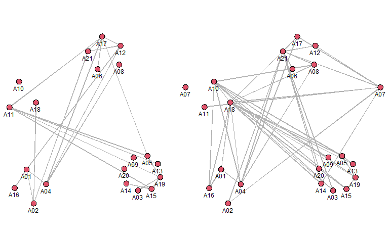

```r
par(op)
```

### Using geographical distance

#### Using the Savage-TransactionFlows network

Check the attributes of this network

```r
Savage_TransactionFlows$Attributes
```

|  | Capital | Latitude | Longitude | X | X.1 | X.2 | X.3 | X.4 | X.5 | X.6 |
| --- | --- | --- | --- | --- | --- | --- | --- | --- | --- | --- |
| UK | London | 51.36 | -0.05 | NA | NA | NA | NA | NA | NA | NA |
| US | WashDC | 39.91 | -77.02 | NA | NA | NA | NA | NA | NA | NA |
| Can | Ottawa | 45.27 | -75.42 | NA | NA | NA | NA | NA | NA | NA |
| Ire | Dublin | 53.21 | -6.15 | NA | NA | NA | NA | NA | NA | NA |
| Ger | Berlin | 52.30 | 13.25 | NA | NA | NA | NA | NA | NA | NA |
| Fran | Paris | 48.50 | 2.20 | NA | NA | NA | NA | NA | NA | NA |
| Belg | Brussels | 50.51 | 4.21 | NA | NA | NA | NA | NA | NA | NA |
| Neth | Amsterdam | 52.23 | 4.54 | NA | NA | NA | NA | NA | NA | NA |
| Italy | Rome | 41.54 | 12.29 | NA | NA | NA | NA | NA | NA | NA |
| Switz | Bern | 46.57 | 7.28 | NA | NA | NA | NA | NA | NA | NA |

[output cut: 5 more lines]

We need to fill up the empty columns in this table for a better visualization. Now the edges distance mean something because we are going to set it to the geographical distance between those countries. However, US and Can are too far away from the rest and plotting them with their current Lat and Long will create a huge plot that is hard to read.

```r
Savage_TransactionFlows$Attributes[,4] <- Savage_TransactionFlows$Attributes$Longitude
Savage_TransactionFlows$Attributes[c(2,3),4] <- Savage_TransactionFlows$Attributes$Longitude[c(2,3)]+30
colnames(Savage_TransactionFlows$Attributes)[4] <- "Longitude_Adj"
Savage_TransactionFlows$Attributes
```

|  | Capital | Latitude | Longitude | Longitude_Adj | X.1 | X.2 | X.3 | X.4 | X.5 | X.6 |
| --- | --- | --- | --- | --- | --- | --- | --- | --- | --- | --- |
| UK | London | 51.36 | -0.05 | -0.05 | NA | NA | NA | NA | NA | NA |
| US | WashDC | 39.91 | -77.02 | -47.02 | NA | NA | NA | NA | NA | NA |
| Can | Ottawa | 45.27 | -75.42 | -45.42 | NA | NA | NA | NA | NA | NA |
| Ire | Dublin | 53.21 | -6.15 | -6.15 | NA | NA | NA | NA | NA | NA |
| Ger | Berlin | 52.30 | 13.25 | 13.25 | NA | NA | NA | NA | NA | NA |
| Fran | Paris | 48.50 | 2.20 | 2.20 | NA | NA | NA | NA | NA | NA |
| Belg | Brussels | 50.51 | 4.21 | 4.21 | NA | NA | NA | NA | NA | NA |
| Neth | Amsterdam | 52.23 | 4.54 | 4.54 | NA | NA | NA | NA | NA | NA |
| Italy | Rome | 41.54 | 12.29 | 12.29 | NA | NA | NA | NA | NA | NA |
| Switz | Bern | 46.57 | 7.28 | 7.28 | NA | NA | NA | NA | NA | NA |

[output cut: 5 more lines]

Symmetrize the network

```r
Savage_TransactionFlows$ExportPerc_SymSqrtProd <- (Savage_TransactionFlows$ExportPerc * t(Savage_TransactionFlows$ExportPerc)) ^.5
Savage_TransactionFlows$NetworkInfo <- rbind(Savage_TransactionFlows$NetworkInfo,c("ExportPerc_SymSqrtProd","A","FALSE","FALSE","Ratio","matrix"))
Savage_TransactionFlows$NetworkInfo
```

| Name | Mode | Directed | Diagonal | Values | Class |
| --- | --- | --- | --- | --- | --- |
| ExportPerc | A | TRUE | FALSE | Ratio | matrix |
| ExportPerc_SymSqrtProd | A | FALSE | FALSE | Ratio | matrix |

Plot

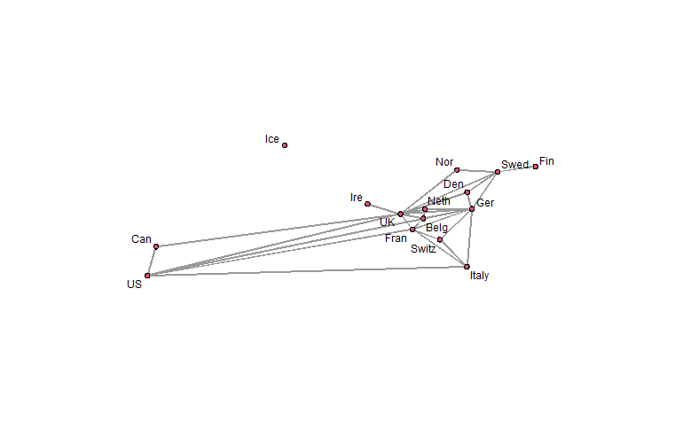

```r
par(mar = c(0, 0, 0, 0), mfrow=c(1,1))
gplot(Savage_TransactionFlows$ExportPerc_SymSqrtProd>5,
      gmode="graph",
      coord=Savage_TransactionFlows$Attributes[,c(4,2)],
      vertex.cex=.3,
      displaylabels=TRUE,
      label.pos=0,
      label.cex=.7,
      edge.col="grey60")
```